# SML 201 Project 1 Speed Dating

# Male and female behavior

### Problem 3 (31 pts)

### Part a (8 pts)

Recall that `prob` is the *rating [given by the participant] on the expected probability that the partner would want to see the participant again* (see question 2.a). For the two genders we would like to analyze and compare the participants’ perception of their partners’ romantic interest. Make a line plot to investigate this.

The plot should have two lines, one for each gender. The x-coordinate of the plot should be the unique values of `prob` and the y-coordinate should be for the fraction of the times the partner would like to see the participant again.

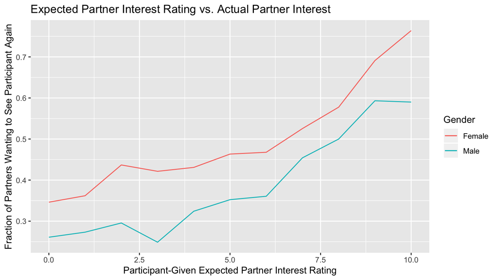

```r
library(ggplot2)
## Separates the data into males and females
dating.f = dating[dating$gender == 0, ]
dating.m = dating[dating$gender == 1, ]
## Calculates the mean fraction of times the partner would like
## to see the participant again
mean.f.dec_o = tapply(X = dating.f$dec_o, INDEX = dating.f$prob,
    FUN = mean)
mean.m.dec_o = tapply(X = dating.m$dec_o, INDEX = dating.m$prob,
    FUN = mean)
## Converts these mean fractions to data frames based on prob
dating.f.2 = data.frame(prob = sort(unique(dating$prob)), dec_o = as.vector(mean.f.dec_o))
dating.m.2 = data.frame(prob = sort(unique(dating$prob)), dec_o = as.vector(mean.m.dec_o))
## Plots the data using ggplot
ggplot() + geom_line(data = dating.f.2, aes(x = prob, y = dec_o,
    colour = "black")) + geom_line(data = dating.m.2, aes(x = prob,
    y = dec_o, colour = "white")) + labs(x = "Participant-Given Expected Partner Interest Rating",
    y = "Fraction of Partners Wanting to See Participant Again",
    title = "Expected Partner Interest Rating vs. Actual Partner Interest",
    colour = "Gender") + scale_colour_discrete(labels = c("Female",
    "Male"))
```

### Part c (11 pts)

Are men or women more likely to want to see their speed dating partners again (please make your answer boldfaced)?

(a.) Female  
(b.) **Male**

Make two histograms, one for each gender, to answer the question above; the histograms should display the distribution of the percentage of times a participant would like to see his/her speed dating partner again. Each participant should contribute exactly one data point to the data that makes the histograms.

You will only be reminded about this once for the entire course so please remember to do this in the future too: To compare multiple distributions the axes of your plots should have the same scale and range limits.

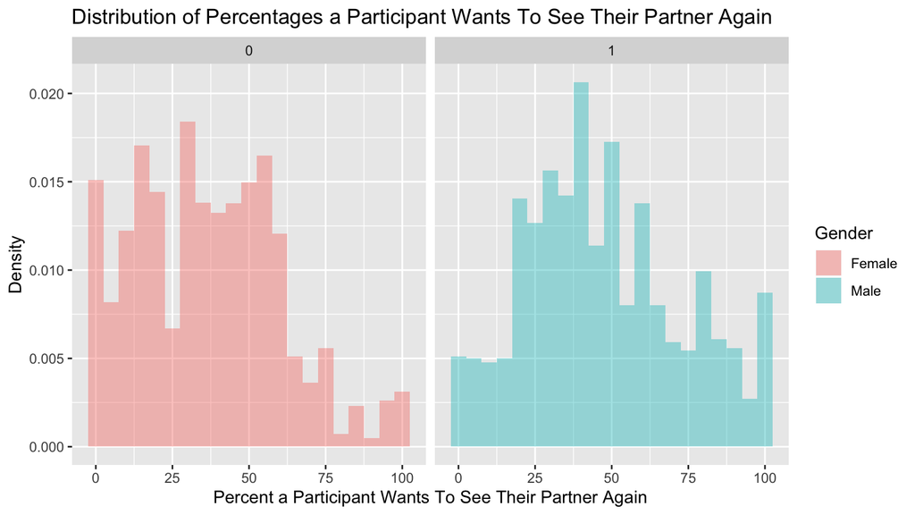

```r
## Calculates the mean percentages for whether or not a
## participants wants to see their partner again
dating.perc = data.frame(number = unique(dating$iid), Percentage = tapply(X = dating$dec,
    INDEX = dating$iid, FUN = mean) * 100)
## Merges dating and dating.perc by iid
dating_merged = merge(x = dating, by.x = "iid", y = dating.perc,
    by.y = "number")
## Plots the data using ggplot
ggplot(dating_merged) + geom_histogram(mapping = aes(x = Percentage,
    y = ..density.., fill = as.factor(gender)), position = "identity",
    binwidth = 5, alpha = 0.4) + facet_grid(. ~ gender) + labs(x = "Percent a Participant Wants To See Their Partner Again",
    y = "Density", title = "Distribution of Percentages a Participant Wants To See Their Partner Again",
    fill = "Gender") + scale_fill_discrete(labels = c("Female",
    "Male"))
```

### Part d (8 pts)

Below is the histogram for a dataset.

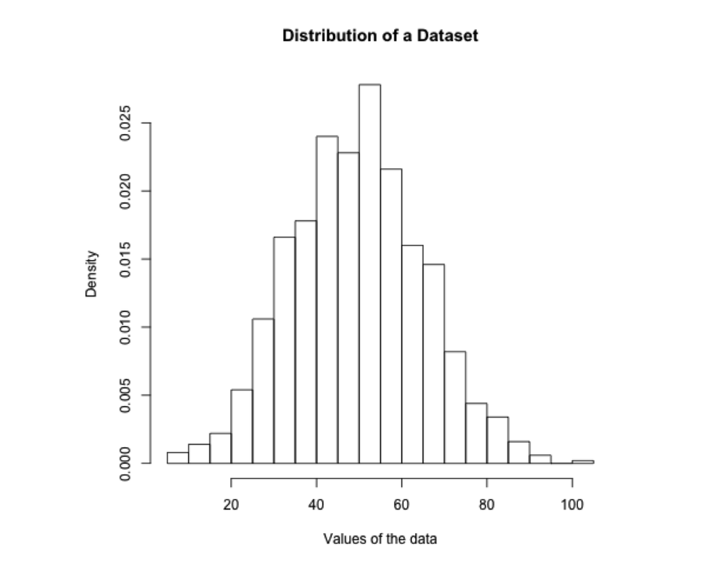

Use the histogram to select the best answer for each of the questions below. No explanation is required.

(4 pts) (i) The minimum of the dataset is approximately around

(A.) -10  
(B.) 0  
(C.) 5  
(D.) 17  
(E.) 20

Answer: C

(4 pts) (ii) You can assume that there are no data points falling on the end points of the bins on the histogram. The percentage of the data points in the dataset that are less than or equal to 20 or greater than or equal to 30 (i.e., the percentage of the data points falling on the interval {$(-\infty, 20] \cup [30, \infty)$} ) is about

(A.) 85%  
(B.) 90%  
(C.) 92%  
(D.) 95%  
(E.) 97%

Answer: C

## Question 4 (24 pts)

### Part a (4 pts)

Subset the variables “iid”, “gender”, “match”, “dec_o”, “exphappy” and “dec” from the dataset `dating` and call this subset `ggpairs.columns`. Use `na.omit()` to extract out the observations in `ggpairs.columns` with complete data only. Name the subset with complete observations as `compl.date`. What percentage of the observations are removed by `na.omit()`? Note that we are removing only a small fraction of our observations.

**Use `compl.date` for the rest of Question 4.**

```r
## Subsets the data, finds the dimensions, omits the NAs, and
## finds the fraction of NAs removed to the total
ggpairs.columns = subset(x = dating, select = c(iid, gender, match,
    dec_o, exphappy, dec))
dim(ggpairs.columns)
[1] 8378    6
compl.date = na.omit(ggpairs.columns)
(nrow(ggpairs.columns) - nrow(compl.date))/nrow(ggpairs.columns)
[1] 0.01205538
```

Answer: 1.2% of the observations are removed by `na.omit()`.

### Part b (2 pts)

Were the values for the variable `exphappy` recorded before, during, or after a speed dating event? Note that the value for `exphappy` was only recorded once in time so this value should be identical for all entries for a given participant.

Answer: The values for `exphappy` were recorded before the speed dating event, according to the data key provided.

### Part c (4 pts)

I have verified that the values for `exphappy` are identical given a participant. Make a vector `ind.exphappy` to store the `exphappy` value for each participant; the length of `ind.exphappy` should be the same as the number of participants.

```r
## Stores the exphappy values for each participant in
## ind.exphappy
ind.exphappy = as.vector(tapply(X = compl.date$exphappy, INDEX = compl.date$iid,
    FUN = mean))
length(ind.exphappy)  # Length = 543
[1] 543
length(unique(compl.date$iid))  # Length = 543
[1] 543
```

### Part d (12 pts)

Create the following variables and use `ggpairs()` in the `GGally` package to make a matrix plot to investigate the pairwise relationship between the variables *within each gender group*:

- gender: The gender of the participant;
- ind.exphappy: The `exphappy` value for each speed dating participant;
- perc.yes: The percentage of the dates the participant wanted to see again;
- perc.partner.yes: The percentage of the dates who would like to see the participant again;
- perc.match: The percentage of matches the participant had.

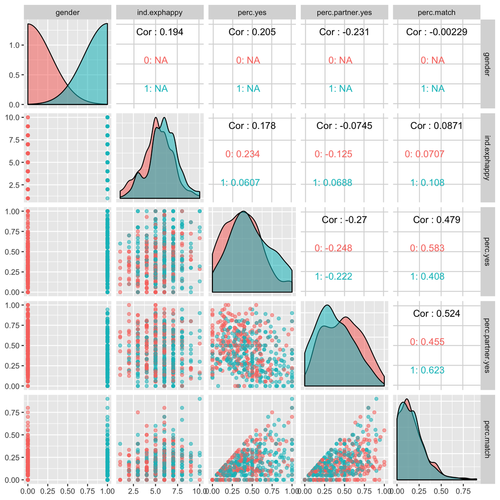

```r
## These tapply functions find the mean for each iid for the
## given category and assign it to that variable
gender = as.vector(tapply(X = compl.date$gender, INDEX = compl.date$iid,
    FUN = mean))
ind.exphappy = as.vector(tapply(X = compl.date$exphappy, INDEX = compl.date$iid,
    FUN = mean))
perc.yes = as.vector(tapply(X = compl.date$dec, INDEX = compl.date$iid,
    FUN = mean))
perc.partner.yes = as.vector(tapply(X = compl.date$dec_o, INDEX = compl.date$iid,
    FUN = mean))
perc.match = as.vector(tapply(X = compl.date$match, INDEX = compl.date$iid,
    FUN = mean))
## Puts those variables into a data frame for use by ggpairs()
compl.date.pairs = data.frame(gender = gender, ind.exphappy = ind.exphappy,
    perc.yes = perc.yes, perc.partner.yes = perc.partner.yes, perc.match = perc.match)
## Plots the pairwise data using ggpairs
ggpairs(compl.date.pairs, aes(color = as.factor(gender), alpha = 0.4))
```

### Part e (2 pts)

Based on your matrix plot in part d answer the following question (no code required): The correlation between `ind.exphappy` and `perc.yes` is stronger for the group of female or male participants? Report the correlation coefficients for the two gender groups.

Answer: The correlation between `ind.exphappy` and `perc.yes` is stronger for the group of female participants. The correlation coefficients between `ind.exphappy` and `perc.yes` for females and males are 0.234 and 0.0607, respectively.

# Self-reported preferences v.s. actual preferences

## Problem 5 (34 pts)

On the survey that were filled out before the speed dating events participants were asked to rank a set of qualities that they were looking for in the opposite sex. These qualities are: Attractiveness, sincerity, intelligence, fun, ambition, and having shared interests. In this problem we are trying to find out if people’s professed thoughts are consistent with their selection criteria. Note that due to the large number of missing values for the variables that we use for this problem the results of the analysis might not be very reliable; nevertheless, we just want to have some fun and see what patterns we can find in the data!

### Part a (No answer required)

Here we extract out the relevant data for question 5: Extract out the columns “iid”, “gender”, “attr1_1”, “sinc1_1”, “intel1_1”, “fun1_1”, “amb1_1”, “shar1_1”, “dec”,  
“attr”, “sinc”, “intel”, “fun”, “amb”, “shar” from the dataset `dating` and the rows for the male participants. Name the resulting data frame `m`.

```r
# Generate subsets
m <- dating[dating$gender == 1, c("iid", "gender", "attr1_1", "sinc1_1",
    "intel1_1", "fun1_1", "amb1_1", "shar1_1", "dec", "attr", "sinc",
    "intel", "fun", "amb", "shar")]
```

### Part b (No answer required)

Then, we extract out the variables “iid”, “gender”, “attr1_1”, “sinc1_1”, “intel1_1”, “fun1_1”, “amb1_1” and “shar1_1” from the dataset `m` and call this subset `male1`.

“attr1_1”, “sinc1_1”, “intel1_1”, “fun1_1”, “amb1_1” and “shar1_1” are the variables recorded on the survey questionnaires about how important the six personality qualities are to a participant in terms of what the participant was looking for in opposite sex (see details in *Speed Dating Data Key.pdf*.) You should take a look at the first few rows of `male1`.

Next, we make a 277 by 6 matrix `m.professed`. Each row of `m.professed` should correspond to a unique male participant and the columns of `m.professed` should correspond to the values of the six personality quality variables reported by the participants on the survey.

```r
# Generate subset
male1 = m[c("iid", "gender", "attr1_1", "sinc1_1", "intel1_1", "fun1_1",
    "amb1_1", "shar1_1")]

# Remove the row duplicates for each male participant
m.professed <- as.matrix(unique(male1)[, 3:8])

dim(m.professed)
[1] 277   6
head(m.professed)
    attr1_1 sinc1_1 intel1_1 fun1_1 amb1_1 shar1_1
101      35      20       20     20      0       5
111      60       0        0     40      0       0
121      19      18       19     18     14      12
131      30       5       15     40      5       5
141      30      10       20     10     10      20
151      50       0       30     10      0      10
```

### Part c (No answer required)

Similarly, we extract out the variables “iid”, “gender”, “dec”,  
“attr”, “sinc”, “intel”, “fun”, “amb” and “shar” from `m`, and call this subset `male2`. Recall that `dec=1` means that the participant would like to see his date again; you should also refresh your memory about the definitions of other variables in `male2`.

```r
# Generate subset
male2 <- m[, c("iid", "gender", "dec", "attr", "sinc", "intel",
    "fun", "amb", "shar")]
```

**Please make sure that you understand what parts a-c do; if not, please ask for clarifications. Also, remember to remove the `eval = F` option in the code chunks for the code to run.**

### Part d: investigate the actual preferences (10 pts)

We want to create a 277 by 6 matrix `m.action`. Each column of `m.action` is for one of the six personality quality attributes. Each row of `m.action` is for one of the male participants. The entry of `m.action` givens the difference in the average ratings between the groups that were accepted and rejected by the participant. e.g., the (1,1) entry of `m.action` is

> average `attr` rating among the dates accepted by participant - average `attr` rating among the dates rejected by participant

for participant with `iid` 11.

Write a function `m.rating.diff`. The function should take one of the attribute columns, `x`, in `male2`, remove the missing data in `x`, and then calculate and return the vector that contains the difference of the average rating between the accepted and the rejected groups for each male participant. The output of `m.rating.diff` should be a vector whose length is equal to the number of male participants.

Recall that you can use `cbind()` (see Ch2.3) to join vectors into a matrix. Use `cbind()` to combine the outputs from `m.rating.diff` to form the matrix `m.action`. Alternately, you are welcome to use the `apply()` function for this step. Please ask help from an instructor if you would like to use `apply()` and have trouble understanding its help page.

```r
## Creates a function m.rating.diff that takes an attribute input
## `y` and returns it as the vector of differences `z`
m.rating.diff = function(x) {
    y = tapply(X = male2[, x], INDEX = list(male2$iid, male2$dec),
        FUN = mean, na.rm = TRUE)
    z = as.vector(apply(y, 1, diff, 1))
    return(z)
}
m.rating.diff(x = "sinc")  ## Testing the user-built function
## Creates the matrix `m.action` based on the six attribute
## vectors
m.action = cbind(m.rating.diff(x = "attr"), m.rating.diff(x = "sinc"),
    m.rating.diff(x = "intel"), m.rating.diff(x = "fun"), m.rating.diff(x = "amb"),
    m.rating.diff(x = "shar"))
m.action
dim(m.action)
```

[output not shown]

### Part e (10 pts)

Make a side-by-side boxplot to compare the distributions of the self-reported importance values across the six personality quality attributes. Similarly, make another side-by-side boxplot to compare the distributions of the average rating difference between the rejected and the accepted groups. See examples of these plots in part g for the females.

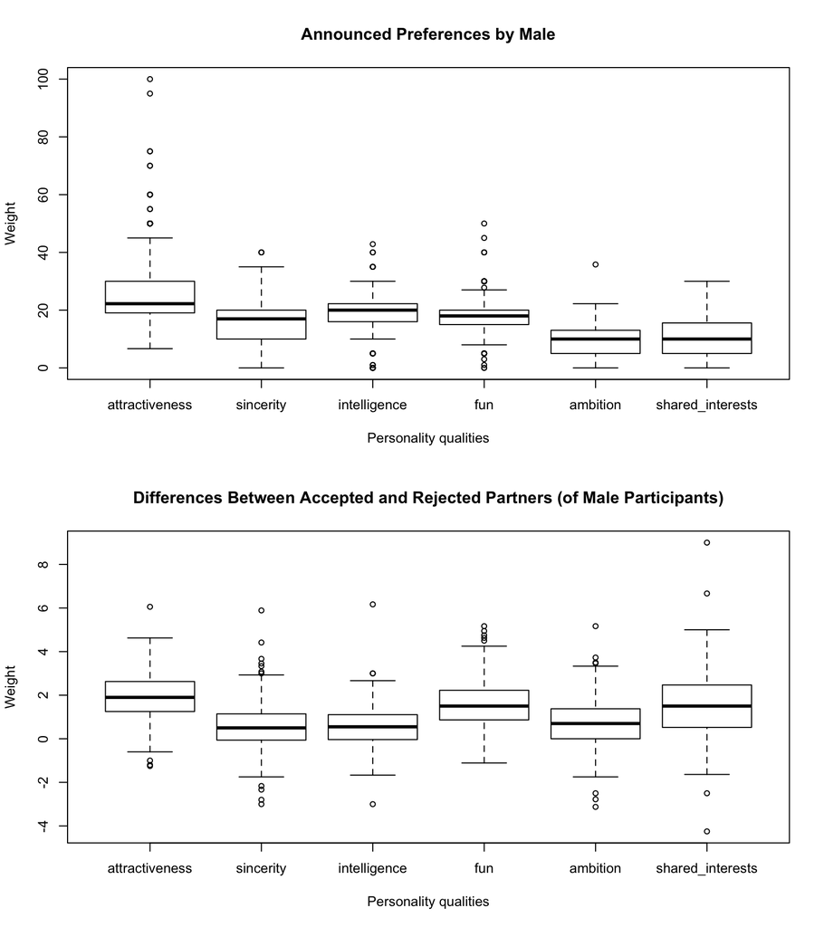

```r
## Makes side-by-side boxplots for both m.professed and m.action
par(mfrow = c(2, 1), cex = 0.8)
boxplot(m.professed, names = c("attractiveness", "sincerity", "intelligence",
    "fun", "ambition", "shared_interests"), main = "Announced Preferences by Male",
    xlab = "Personality qualities", ylab = "Weight")
boxplot(m.action, names = c("attractiveness", "sincerity", "intelligence",
    "fun", "ambition", "shared_interests"), main = "Differences Between Accepted and Rejected Partners (of Male Participants)",
    xlab = "Personality qualities", ylab = "Weight")
```

### Part f (6 pts)

Based on your plots in part e what are the top three qualities of a date that the male participants think are the most important to them? What are the top three qualities that separate the rejected group from the accepted group of dates for the male participants? Use the 1st, 2nd and 3rd quartiles as measures to pick out the top qualities. (No code is required for this part.)

Answer: The top three qualities of a date that the male participants think are the most important to them are **attractiveness**, **intelligence**, and **fun**. In reality, the top three qualities that differentiate the rejected group from the accepted group of dates for the male participants are **attractiveness**, **fun**, and **shared interests**.

### Part g (4 pts)

I have done steps similar to part a-e for the female participants for you. Below are the two side-by-side boxplots for the female participants.

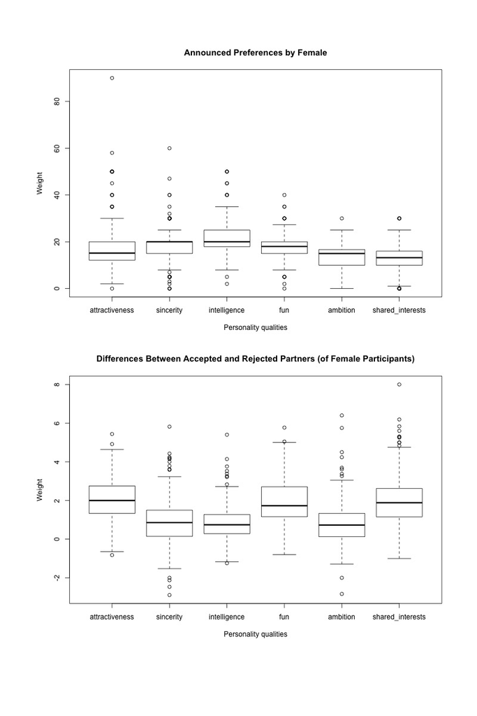

Based on the plots what are the top three qualities of a date that the female participants think were the most important to them? What are the top three qualities that separate the rejected group from the accepted group of dates for the female participants? Use the 1st, 2nd and 3rd quartiles as measures to pick out the top qualities. (No code is required for this part.)

Answer: The top three qualities of a date that the female participants think are the most important to them are **sincerity**, **intelligence**, and **fun**. In reality, the top three qualities that differentiate the rejected group from the accepted group of dates for the female participants are **attractiveness**, **fun**, and **shared interests**.

### Part h (4 pts)

Is the attribute intelligence among the top three announced preferences for the males and the females? Is the attribute intelligence among the top three observed preferences for the males and the females based on the data?

Answer: Yes, intelligence is in the top three announced attribute preferences for both the males and the females, but intelligence is not in the top three observed preferences for both.

Were the attributes attractiveness and shared interests among the top three announced preferences for the females? What about among the top three observed preferences for the males and the females based on the data?

Answer: No, attractiveness and shared interests are not among the top three announced attribute preferences for the females. In contrast, both attractiveness and shared interests are in the top three observed preferences for both the males and the females.